# Rasch Rating Scale Analysis: Passion for Profession Scale

Adenigbagbe Abosede Precious-Gold

March 28, 2026

# 1 Data Description and Preparation

The Passion for Profession scale comprises 10 items measuring undergraduate students’ engagement with and enthusiasm for their chosen field of study. Responses were recorded on a 6-point Likert-type format ranging from 1 (*Strongly Disagree*) to 6 (*Strongly Agree*). Before analysis, two preprocessing steps were required.

First, item profes10 (“If I had the opportunity, I would choose a different profession.”) is the only negatively worded item in the scale. A high score on this item reflects *low* passion — the opposite direction of all other items. If left uncorrected, profes10 would correlate negatively with the rest of the scale and distort all subsequent analyses. It was therefore reverse coded prior to any analysis using the formula: new score = 7 − original score, so that higher scores consistently reflect greater passion across all items.

Second, extreme scorers — respondents who selected the minimum or maximum response on every item — were identified and removed, as such patterns carry no psychometric information in Rasch modelling (Bond & Fox, 2015).

Extreme Scorer Screening Summary

| Metric | Value |
| --- | --- |
| Extreme scorers identified | 1 |
| Participants removed | 1 |
| Final analytic sample | 244 |

Table 1. Descriptive Statistics for Scale Items (N = 244)

|  | Item | n | mean | sd | min | max | skew | kurtosis |
| --- | --- | --- | --- | --- | --- | --- | --- | --- |
| profes01 | I am interested in what I do within my profession. | 244 | 3.7 | 1.06 | 1 | 6 | -0.59 | -0.17 |
| profes02 | What attracts me to my profession is the opportunity to learn something new. | 244 | 3.9 | 0.96 | 1 | 6 | -0.64 | 0.19 |
| profes03 | With each month, I feel my professional knowledge growing. | 244 | 3.6 | 1.08 | 1 | 6 | -0.31 | -0.62 |
| profes04 | I like the people who work in my profession. | 244 | 3.9 | 0.97 | 1 | 6 | -0.62 | 0.22 |
| profes05 | I believe that my future job has an important purpose and meaning. | 244 | 4.1 | 1.07 | 1 | 6 | -0.89 | -0.09 |
| profes06 | I feel enthusiastic about my profession. | 244 | 3.7 | 1.15 | 1 | 6 | -0.58 | -0.51 |
| profes07 | I feel proud when I talk about what I am studying. | 244 | 3.8 | 1.14 | 1 | 6 | -0.60 | -0.39 |
| profes08 | I believe that my profession is important for society. | 244 | 4.3 | 0.99 | 1 | 6 | -1.26 | 1.07 |
| profes09 | I believe that working in my profession is prestigious. | 244 | 3.8 | 1.13 | 1 | 6 | -0.60 | -0.56 |
| profes10 | If I had the opportunity, I would choose a different profession. [R] | 244 | 4.0 | 1.07 | 2 | 6 | -0.62 | -0.82 |

Table 2. Response Frequency per Category

|  | Strongly Disagree (1) | Disagree (2) | Rather Disagree (3) | Rather Agree (4) | Agree (5) | Strongly Agree (6) |
| --- | --- | --- | --- | --- | --- | --- |
| profes01 | 8 | 23 | 58 | 92 | 62 | 1 |
| profes02 | 5 | 12 | 60 | 95 | 71 | 1 |
| profes03 | 7 | 29 | 75 | 71 | 61 | 1 |
| profes04 | 6 | 11 | 65 | 93 | 68 | 1 |
| profes05 | 5 | 17 | 48 | 56 | 117 | 1 |
| profes06 | 10 | 30 | 51 | 79 | 73 | 1 |
| profes07 | 11 | 21 | 63 | 68 | 80 | 1 |
| profes08 | 5 | 9 | 37 | 59 | 133 | 1 |
| profes09 | 7 | 29 | 51 | 72 | 84 | 1 |
| profes10 | 0 | 34 | 37 | 71 | 100 | 2 |

The final analytic sample comprised **N = 244 participants** after one extreme scorer was identified and removed. No missing data were detected. Item means ranged from *M* = 3.60 (*SD* = 1.08; profes03) to *M* = 4.30 (*SD* = 0.99; profes08), indicating that respondents generally leaned toward agreement. All items demonstrated mild negative skew, reflecting a ceiling tendency. A critical observation is that response category 6 (*Strongly Agree*) was endorsed by only **one respondent per item** across the entire scale (two for profes10). This near-zero endorsement rate violates the minimum threshold of 10 observations per category required for stable Rasch estimation (Linacre, 2002) and will be formally addressed in the optimization stage.

# 2 Reliability and Descriptives

Reliability was assessed using two complementary indices. **Cronbach’s alpha** provides a classical test theory estimate of internal consistency. **EAP Person Reliability** is a Rasch-specific index reflecting the precision with which the scale separates respondents along the latent continuum. Both are interpreted against the benchmark of $>= .70$ (acceptable) and $>= .80$ (good; Kline, 2000).

Table 3. Reliability Indices — Initial Model

| Statistic | Value | Benchmark |
| --- | --- | --- |
| Cronbach’s Alpha (Classical Test Theory) | 0.93 | >= .70 acceptable >= .80 good |
| EAP Person Reliability (Rasch) | 0.92 | >= .70 acceptable >= .80 good |
| Person Separation Reliability (WLE) | 0.91 | >= .70 acceptable >= .80 good |

Table 4. Item Discrimination: Point-Measure Correlations

|  | raw.r | r.drop |
| --- | --- | --- |
| profes01 | 0.80 | 0.74 |
| profes02 | 0.84 | 0.80 |
| profes03 | 0.78 | 0.72 |
| profes04 | 0.75 | 0.69 |
| profes05 | 0.79 | 0.73 |
| profes06 | 0.84 | 0.79 |
| profes07 | 0.81 | 0.75 |
| profes08 | 0.73 | 0.67 |
| profes09 | 0.78 | 0.72 |
| profes10 | 0.65 | 0.56 |

Cronbach’s alpha was alpha = 0.93, indicating good internal consistency. EAP Person Reliability was 0.92, confirming the scale’s capacity to reliably differentiate respondents along the latent continuum of passion for profession. Both indices exceed the $>= .80$ threshold. Person separation reliability *(WLE)* was 0.91, consistent with the EAP estimate, confirming the scale’s capacity to reliably differentiate respondents. All items demonstrated adequate discrimination, with corrected item-total correlations (*r*-drop) ranging from .56 (profes10) to $.80$ **(profes02)**, all exceeding the minimum threshold of $.30$. The comparatively lower discrimination of **profes10** (*r*-drop = .56) is consistent with its reverse-coded nature and will be examined further in the fit analysis.

# 3 Dimensionality

The Rasch Rating Scale Model assumes **unidimensionality** — that a single latent trait underlies all item responses. This was assessed via principal components analysis (PCA) of Rasch residuals. After the primary Rasch dimension is extracted, remaining residuals should contain no further systematic variance if the scale is truly unidimensional. The key criterion is that the eigenvalue of the first residual component should fall below **2.0** — equivalent to less than two items’ worth of unexplained systematic variance (Linacre, 1998).

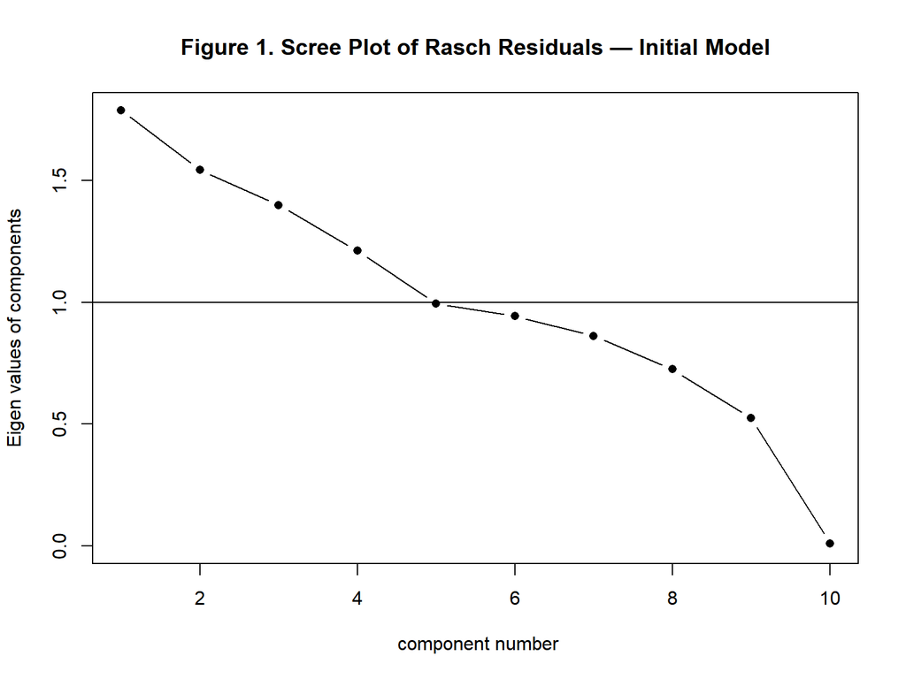

Table 5. Eigenvalues of PCA on Rasch Residuals — Initial Model (First 10 Components)

| Component | Eigenvalue | Variance_Explained |
| --- | --- | --- |
| PC1 | 1.79 | 17.88% |
| PC2 | 1.54 | 15.43% |
| PC3 | 1.40 | 13.99% |
| PC4 | 1.21 | 12.11% |
| PC5 | 1.00 | 9.95% |
| PC6 | 0.94 | 9.44% |
| PC7 | 0.86 | 8.62% |
| PC8 | 0.72 | 7.24% |
| PC9 | 0.52 | 5.25% |
| PC10 | 0.01 | 0.11% |

The eigenvalue of the first residual contrast was 1.79, falling below the unidimensionality threshold of 2.0, which supports the assumption of unidimensionality. Subsequent components also declined substantially (PC2 = 1.54, PC3 = 1.4), and no clearly interpretable secondary dimension was identified. The scale is therefore considered **unidimensional**, and the Rasch Rating Scale Model is an appropriate analytical framework for this data.

# 4 Model Fit

Item fit in Rasch modelling is evaluated using **Infit** and **Outfit Mean Square (MnSq)** statistics and their *Z*-standardized (*ZSt*) equivalents. Infit is sensitive to unexpected responses near an item’s difficulty level; Outfit is more sensitive to outlier responses far from item difficulty. For a rating scale survey, acceptable MnSq values fall between **0.6 and 1.4**, with *ZSt* within **+/-2.0** (Wright & Linacre, 1994). Values above 1.4 indicate **underfit** — the item behaves more randomly than expected. Values below 0.6 indicate **overfit** — responses are overly deterministic and the item may be redundant.

Table 6. Item Fit Statistics — Initial Model (Acceptable: MnSq 0.6-1.4, |ZSt| < 2.0)

| Item | Infit_MnSq | Infit_ZSt | Outfit_MnSq | Outfit_ZSt | Infit_Flag | Outfit_Flag |
| --- | --- | --- | --- | --- | --- | --- |
| profes01 | 0.89 | -1.23 | 0.92 | -0.78 | ok | ok |
| profes02 | 0.65 | -4.22 | 0.66 | -3.50 | misfit | misfit |
| profes03 | 0.94 | -0.65 | 0.95 | -0.48 | ok | ok |
| profes04 | 0.95 | -0.53 | 1.01 | 0.09 | ok | ok |
| profes05 | 1.09 | 0.95 | 0.94 | -0.46 | ok | ok |
| profes06 | 0.88 | -1.30 | 0.86 | -1.42 | ok | ok |
| profes07 | 1.01 | 0.12 | 0.97 | -0.26 | ok | ok |
| profes08 | 1.21 | 2.01 | 0.95 | -0.35 | misfit | ok |
| profes09 | 1.09 | 0.95 | 1.06 | 0.63 | ok | ok |
| profes10 | 1.52 | 4.78 | 1.90 | 6.46 | misfit | misfit |

Item fit statistics revealed acceptable performance for the majority of items, with two notable exceptions. **profes10** demonstrated severe underfit $(Infit\ MnSq = 1.52,\ ZSt = 4.78;\ Outfit\ MnSq = 1.90,\ ZSt = 6.46)$, indicating responses considerably more random than the model expects — consistent with its reverse-coded nature and lowest point-measure correlation (*r*-drop = .56). **profes02** showed overfit (*Infit MnSq* = 0.65, *ZSt* = -4.22; *Outfit MnSq* = 0.66, *ZSt* = -3.50), suggesting overly predictable responses and possible item redundancy. **profes08** showed a borderline Infit *ZSt* = 2.01, which is statistically flagged; however, its MnSq of 1.21 remains well within the acceptable 0.6–1.4 range. Because ZSt is sensitive to sample size and MnSq is considered the primary substantive criterion (Wright & Linacre, 1994), profes08 is not flagged for removal at this stage but will be monitored across subsequent iterations. All remaining seven items demonstrated adequate fit. **profes10** is the primary candidate for removal in the optimization stage.

# 5 Item Continuum and Thresholds

The **Wright Map** places both person abilities and item difficulty parameters on the same logit scale, enabling direct assessment of scale targeting. Adequate targeting occurs when item thresholds span the full range of person abilities. **Category Probability Curves** display the probability of choosing each response category across the latent trait — well-functioning categories show non-overlapping, ordered curves with distinct modal peaks. **Disordered thresholds** occur when a category is never the most probable response at any point on the scale. Threshold distances between adjacent categories should exceed **0.8 logits** and remain below **5.0 logits** (Linacre, 2002).

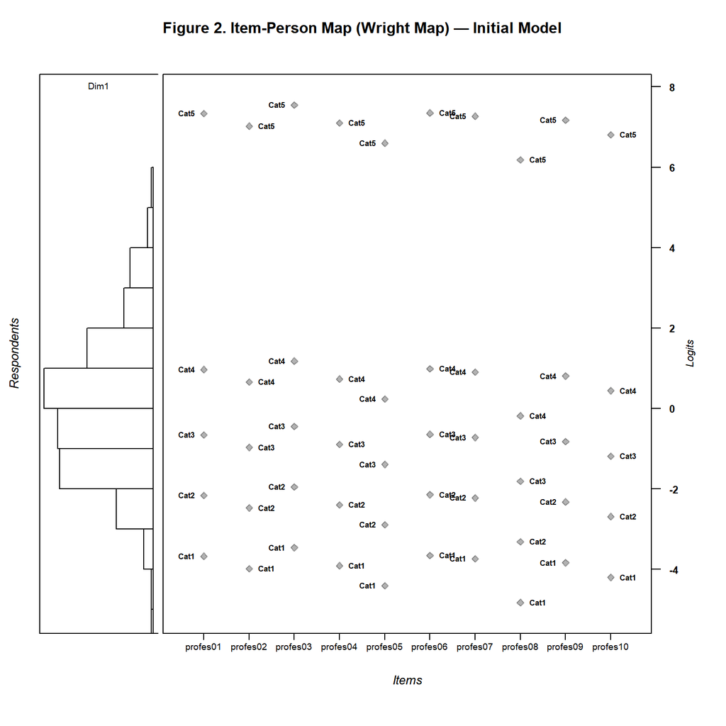

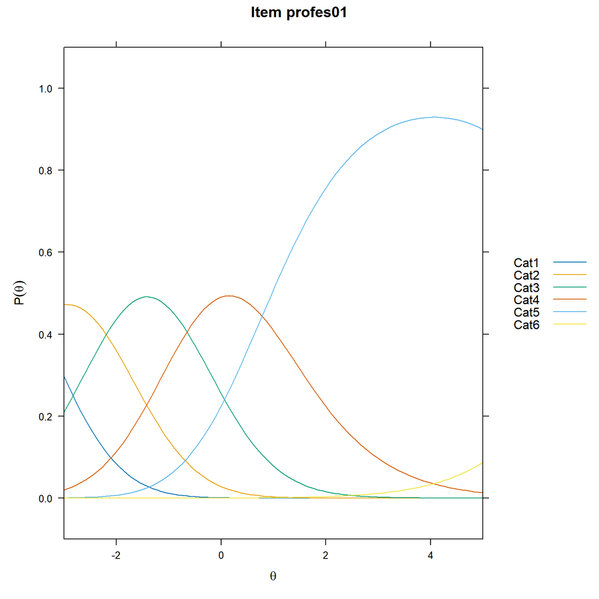

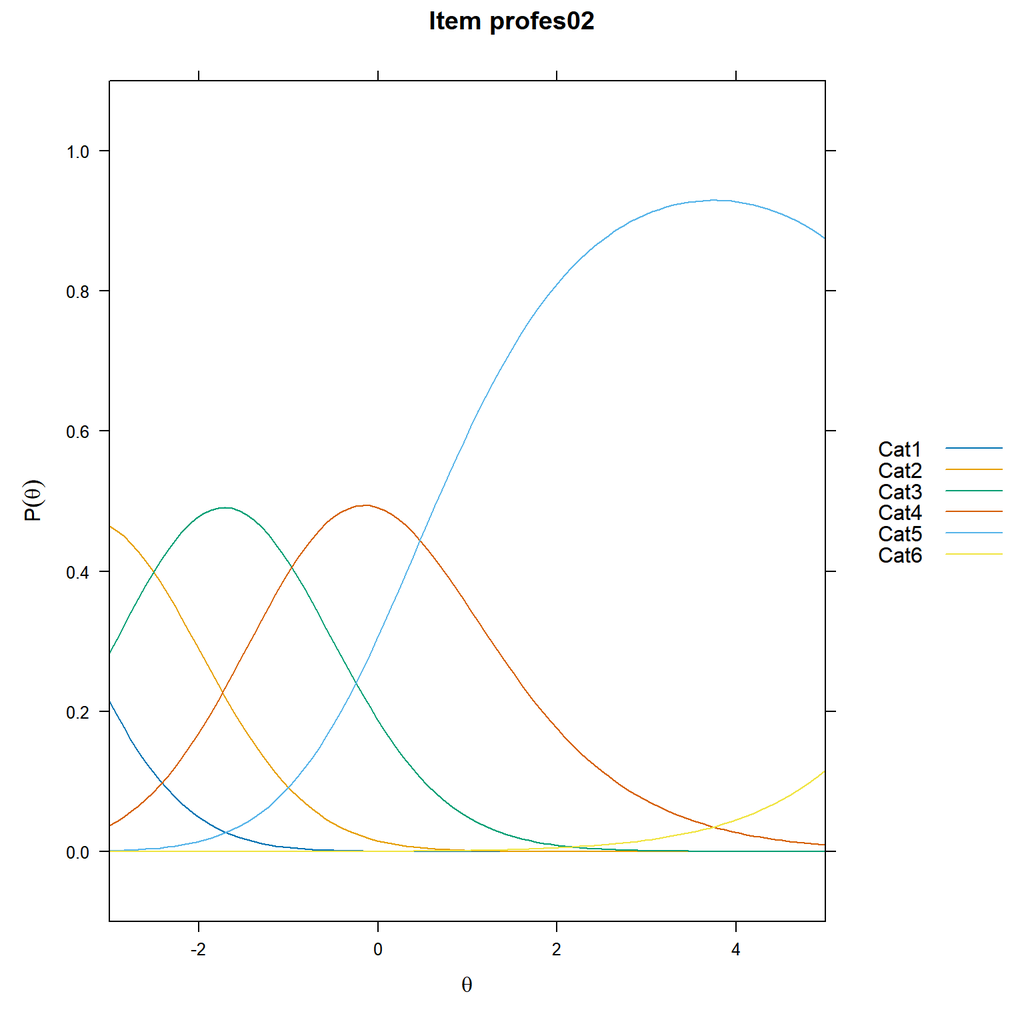

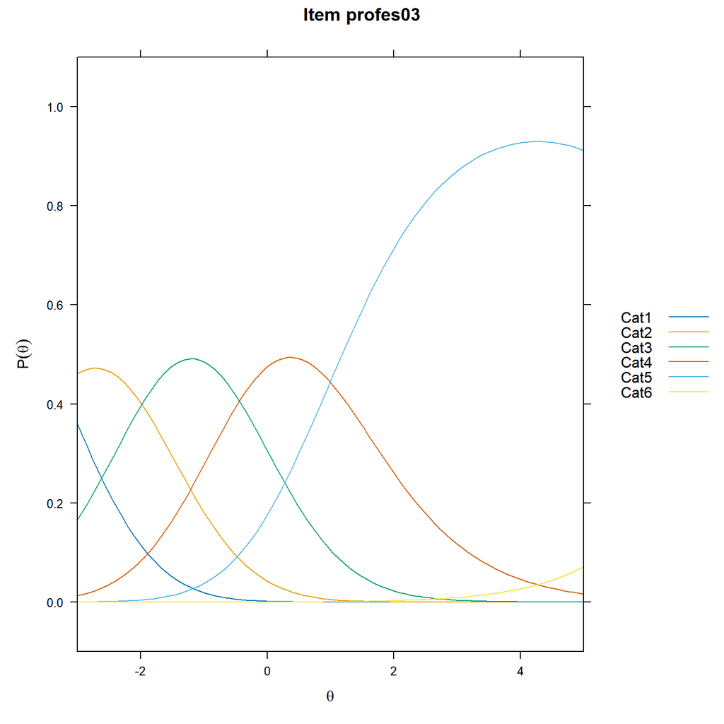

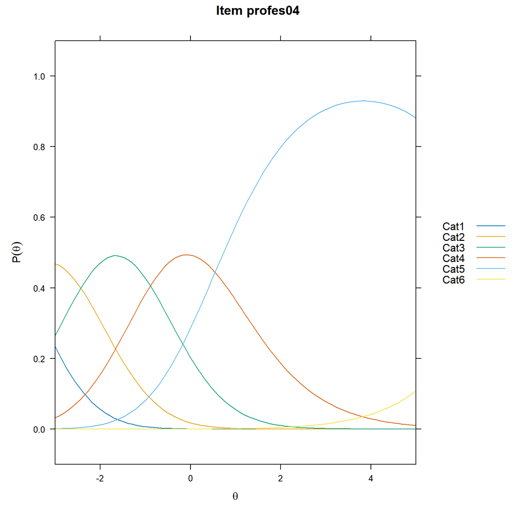

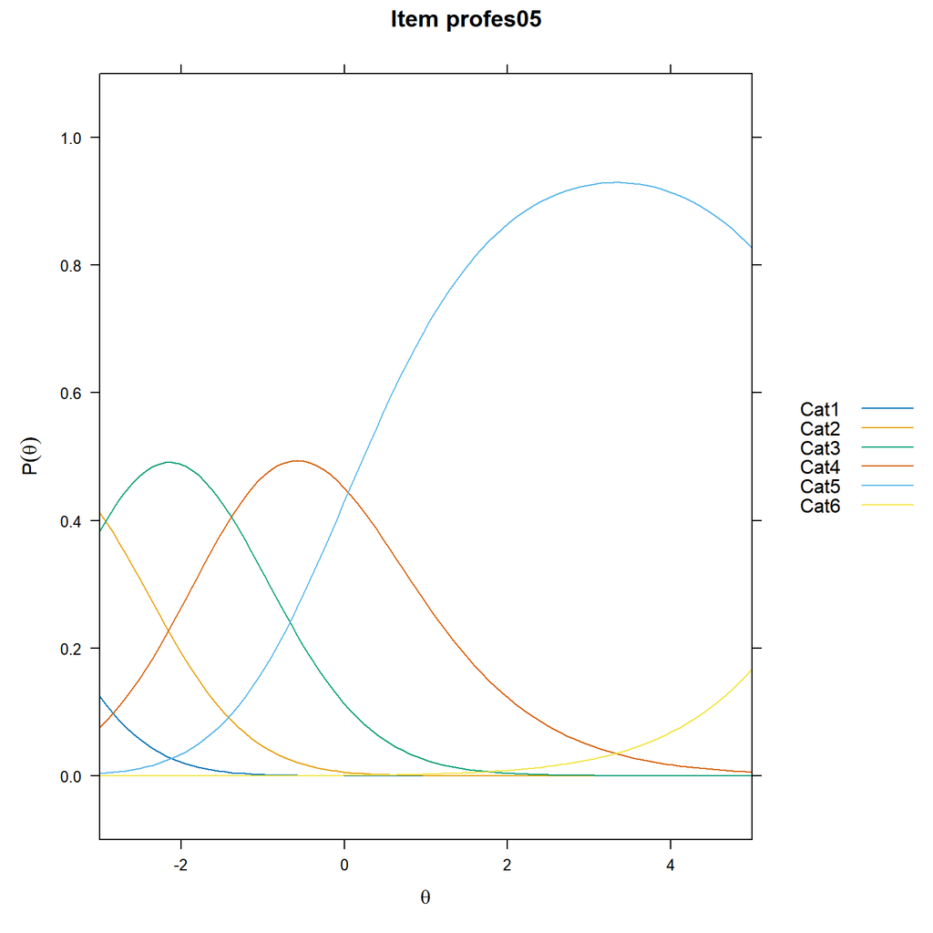

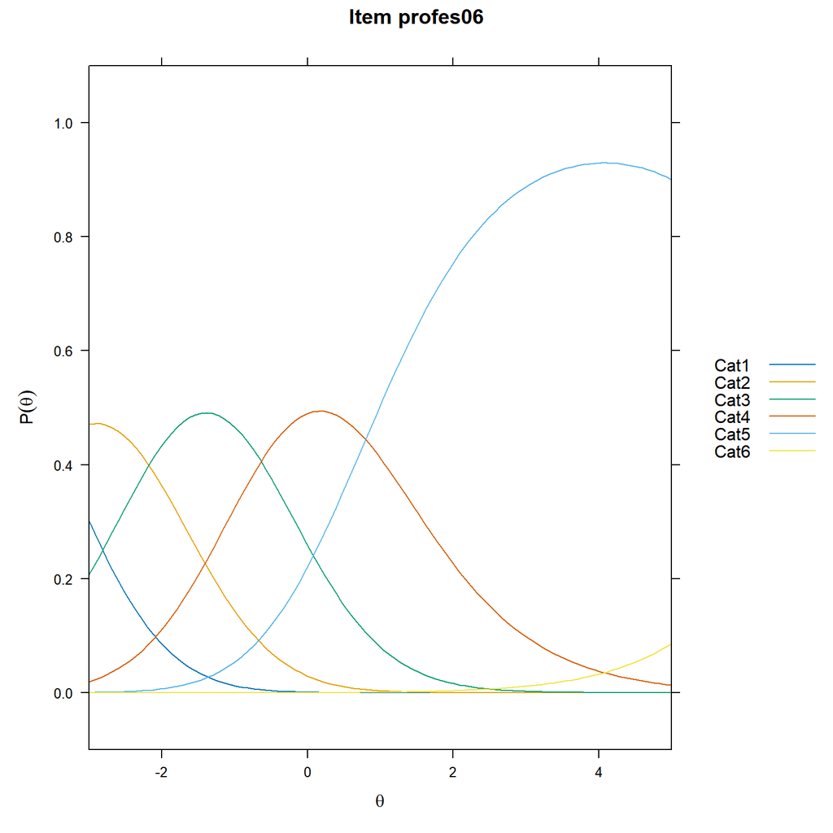

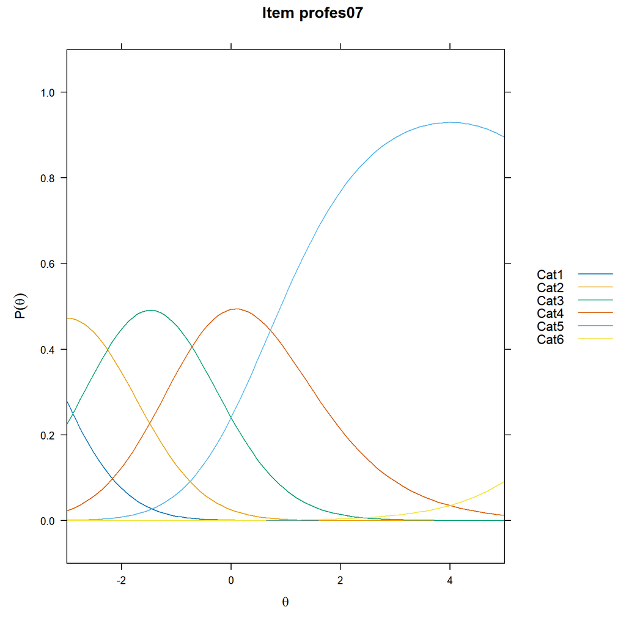

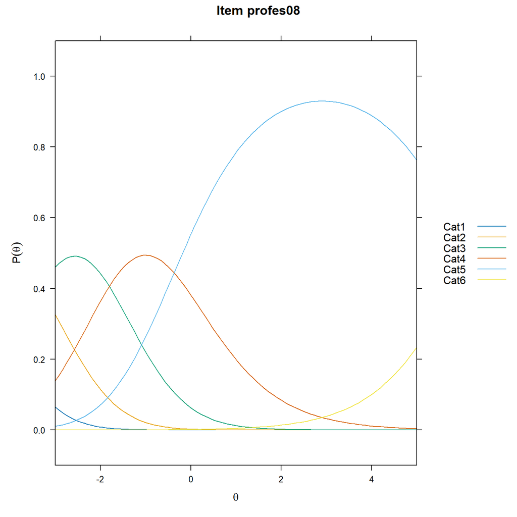

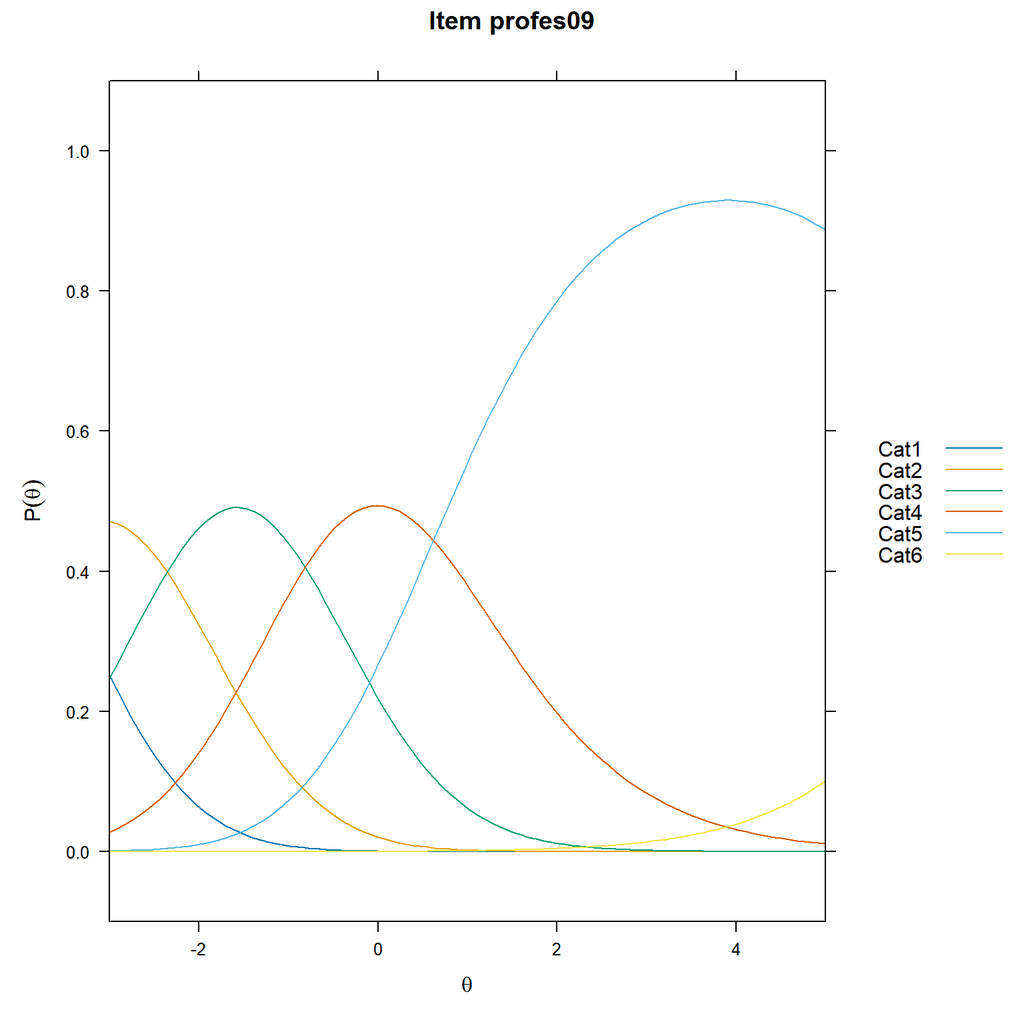

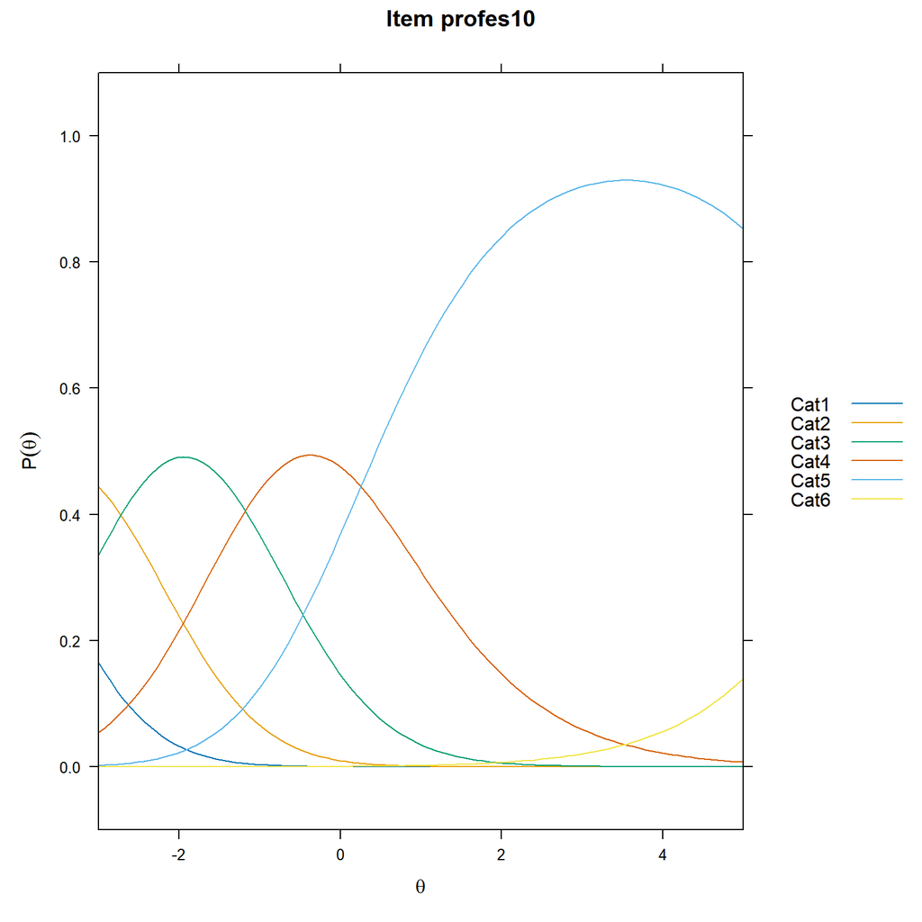

Table 7. Item IRT Parameters and Threshold Locations — Initial Model

|  | alpha | beta | tau.Cat1 | tau.Cat2 | tau.Cat3 | tau.Cat4 | tau.Cat5 |
| --- | --- | --- | --- | --- | --- | --- | --- |
| profes01 | 1 | 0.36 | -3.8 | -2.6 | -1 | 0.42 | 7 |
| profes02 | 1 | 0.05 | -3.8 | -2.6 | -1 | 0.42 | 7 |
| profes03 | 1 | 0.57 | -3.8 | -2.6 | -1 | 0.42 | 7 |
| profes04 | 1 | 0.12 | -3.8 | -2.6 | -1 | 0.42 | 7 |
| profes05 | 1 | -0.37 | -3.8 | -2.6 | -1 | 0.42 | 7 |
| profes06 | 1 | 0.38 | -3.8 | -2.6 | -1 | 0.42 | 7 |
| profes07 | 1 | 0.30 | -3.8 | -2.6 | -1 | 0.42 | 7 |
| profes08 | 1 | -0.79 | -3.8 | -2.6 | -1 | 0.42 | 7 |
| profes09 | 1 | 0.20 | -3.8 | -2.6 | -1 | 0.42 | 7 |
| profes10 | 1 | -0.17 | -3.8 | -2.6 | -1 | 0.42 | 7 |

# 6 Scale Optimization

**Goal:** Achieve ordered thresholds, adequate threshold distances (> 0.8, < 5.0 logits), sufficient category frequencies (>= 10 per category), and acceptable item fit (MnSq 0.6-1.4) through a systematic iterative process.

The optimization followed guidelines by Smith et al. (2003): categories with fewer than 10 observations should be collapsed with adjacent categories; misfitting items should be removed one at a time with diagnostics re-evaluated after each change.

## 6.1 Iteration 1: Collapse Top Response Category

**Rationale:** Response category 6 (*Strongly Agree*, coded as 5 in the 0-based scale) was endorsed by only 1-2 respondents per item. This violates the minimum threshold of 10 observations per category (Linacre, 2002) and produces unrealistically high threshold locations (6-8 logits). Categories 4 and 5 (original 5 and 6) were collapsed into a single category, reducing the scale from 6-point to **5-point (0-4)**.

Table 8. Item Fit — Iteration 1 (5-Point Scale, 0-4)

| Item | Infit_MnSq | Infit_ZSt | Outfit_MnSq | Outfit_ZSt | Infit_Flag | Outfit_Flag |
| --- | --- | --- | --- | --- | --- | --- |
| profes01 | 0.89 | -1.21 | 0.91 | -0.73 | ok | ok |
| profes02 | 0.65 | -4.29 | 0.64 | -3.12 | misfit | misfit |
| profes03 | 0.94 | -0.64 | 0.94 | -0.56 | ok | ok |
| profes04 | 0.95 | -0.52 | 1.03 | 0.25 | ok | ok |
| profes05 | 1.10 | 1.08 | 0.94 | -0.34 | ok | ok |
| profes06 | 0.88 | -1.32 | 0.84 | -1.45 | ok | ok |
| profes07 | 1.01 | 0.11 | 0.97 | -0.24 | ok | ok |
| profes08 | 1.24 | 2.25 | 0.96 | -0.17 | misfit | ok |
| profes09 | 1.09 | 0.96 | 1.06 | 0.53 | ok | ok |
| profes10 | 1.52 | 4.74 | 1.93 | 5.32 | misfit | misfit |

Table 9. Threshold Locations — Iteration 1

|  | alpha | beta | tau.Cat1 | tau.Cat2 | tau.Cat3 | tau.Cat4 |
| --- | --- | --- | --- | --- | --- | --- |
| profes01 | 1 | -1.4 | -2.1 | -0.81 | 0.73 | 2.2 |
| profes02 | 1 | -1.7 | -2.1 | -0.81 | 0.73 | 2.2 |
| profes03 | 1 | -1.1 | -2.1 | -0.81 | 0.73 | 2.2 |
| profes04 | 1 | -1.6 | -2.1 | -0.81 | 0.73 | 2.2 |
| profes05 | 1 | -2.1 | -2.1 | -0.81 | 0.73 | 2.2 |
| profes06 | 1 | -1.3 | -2.1 | -0.81 | 0.73 | 2.2 |
| profes07 | 1 | -1.4 | -2.1 | -0.81 | 0.73 | 2.2 |
| profes08 | 1 | -2.5 | -2.1 | -0.81 | 0.73 | 2.2 |
| profes09 | 1 | -1.5 | -2.1 | -0.81 | 0.73 | 2.2 |
| profes10 | 1 | -1.9 | -2.1 | -0.81 | 0.73 | 2.2 |

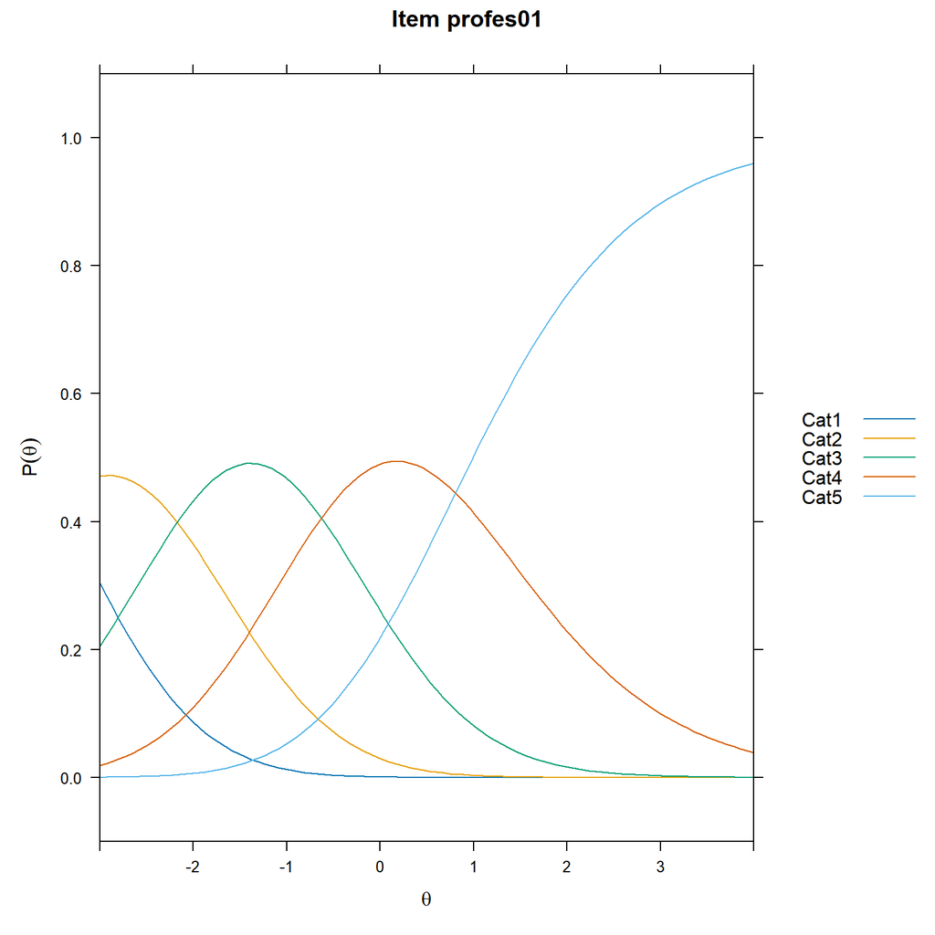

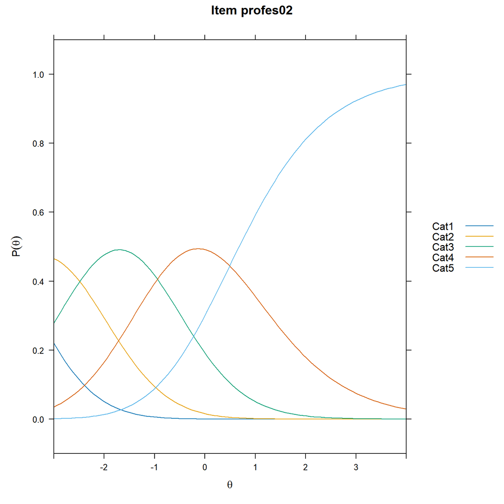

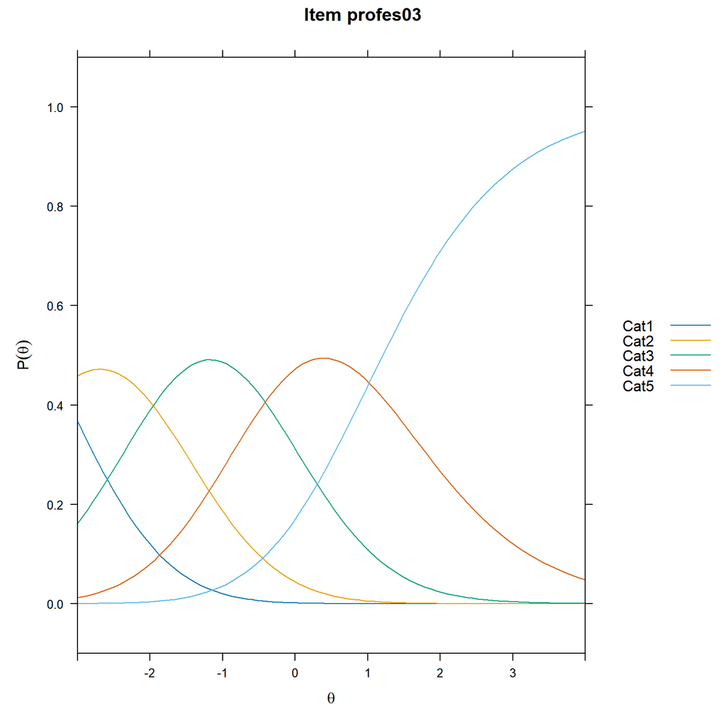

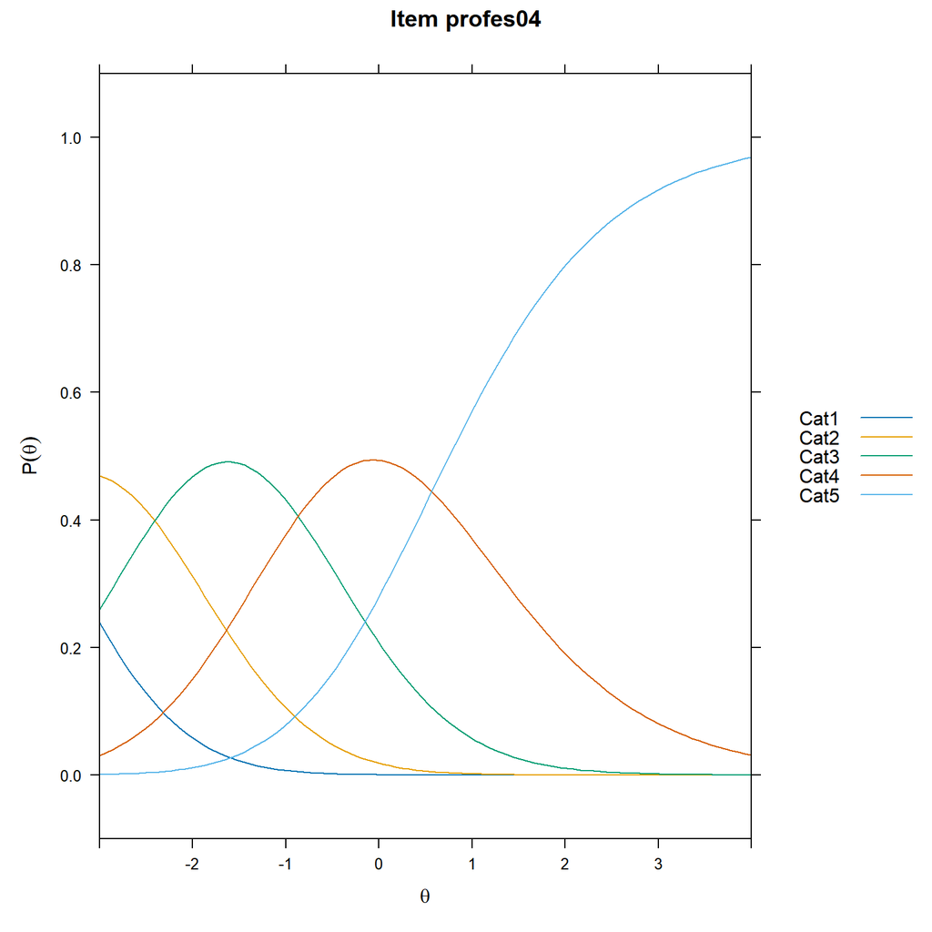

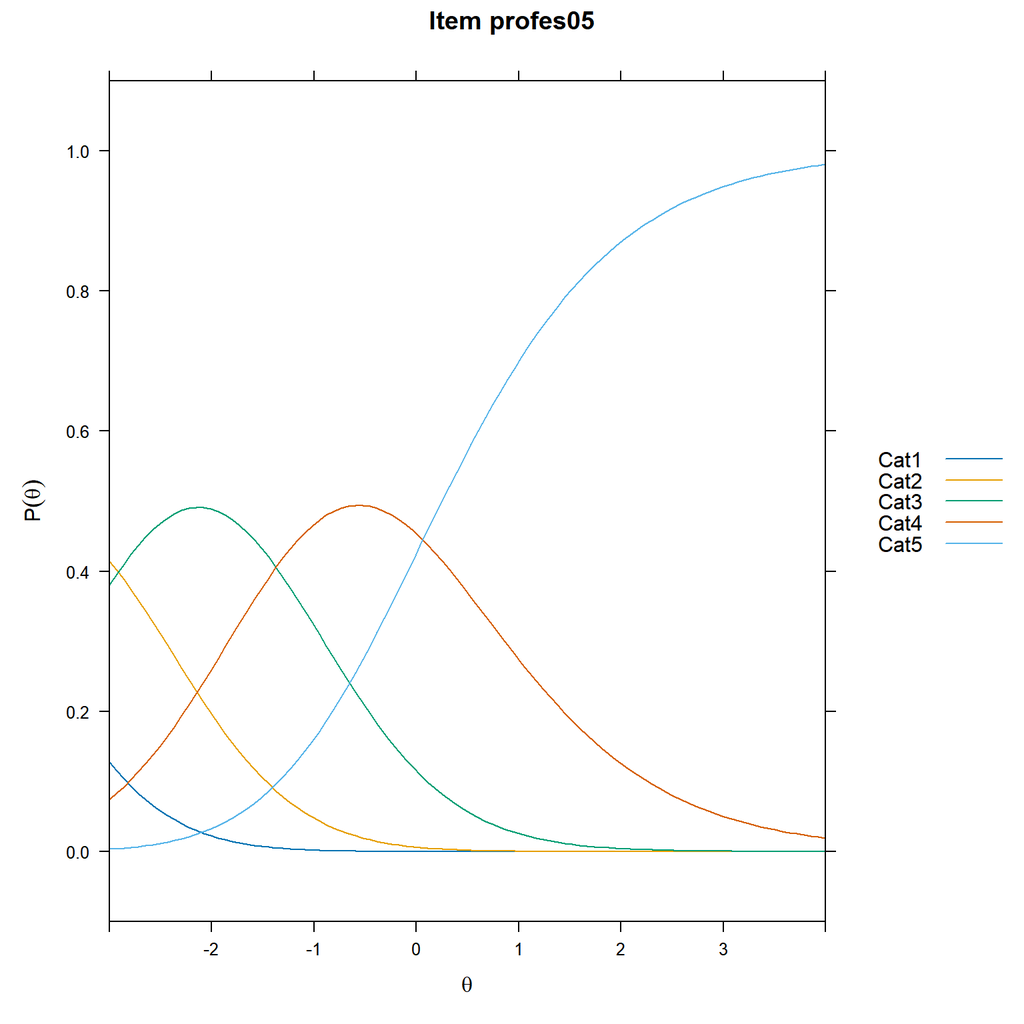

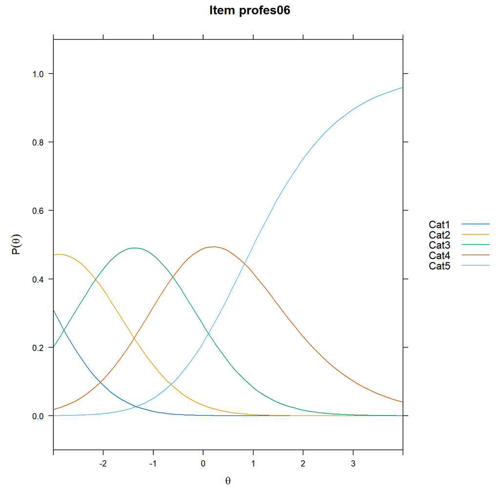

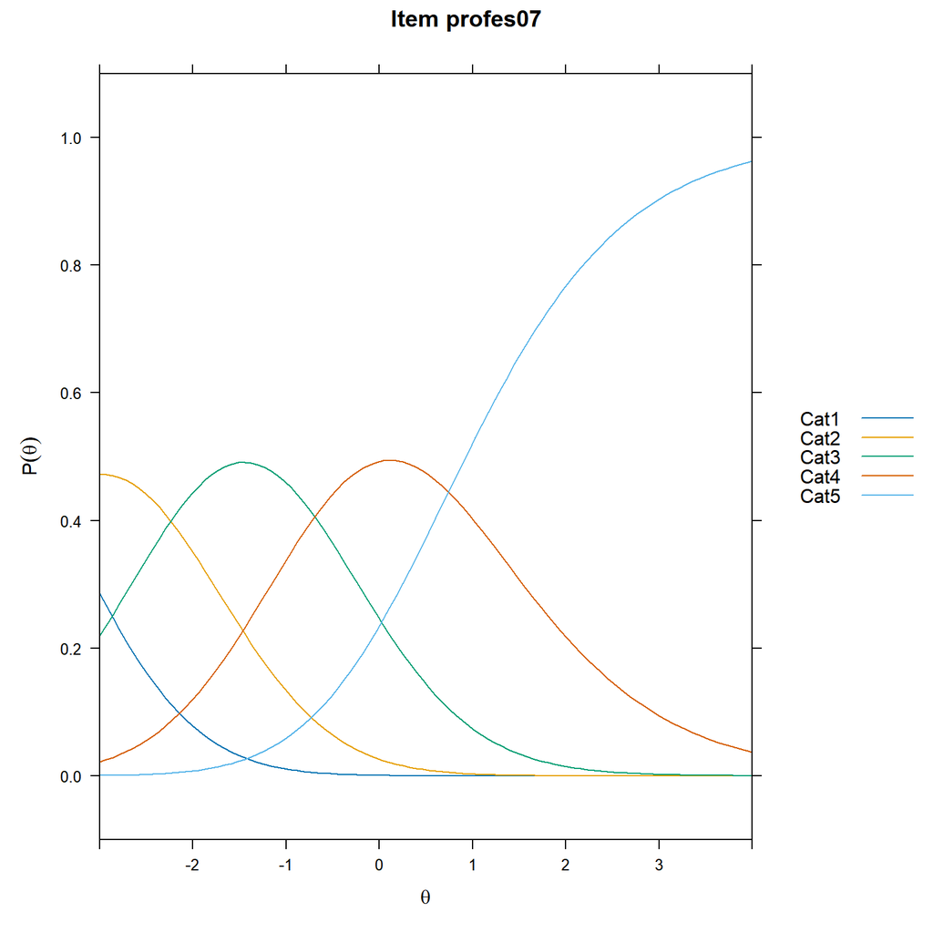

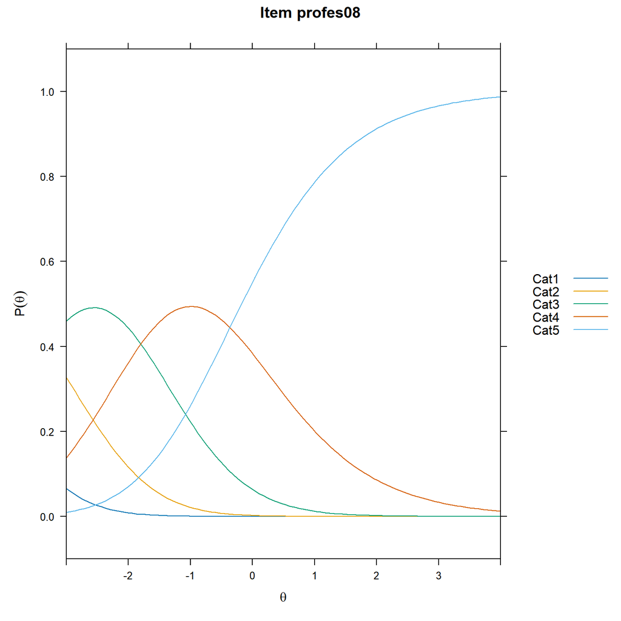

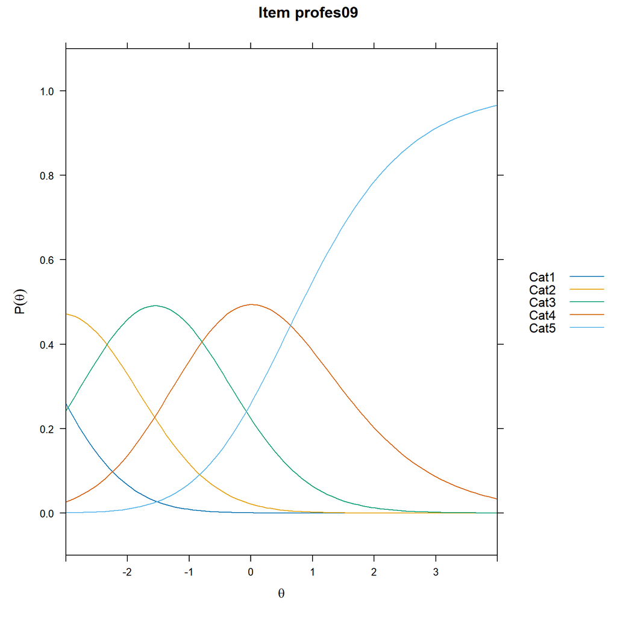

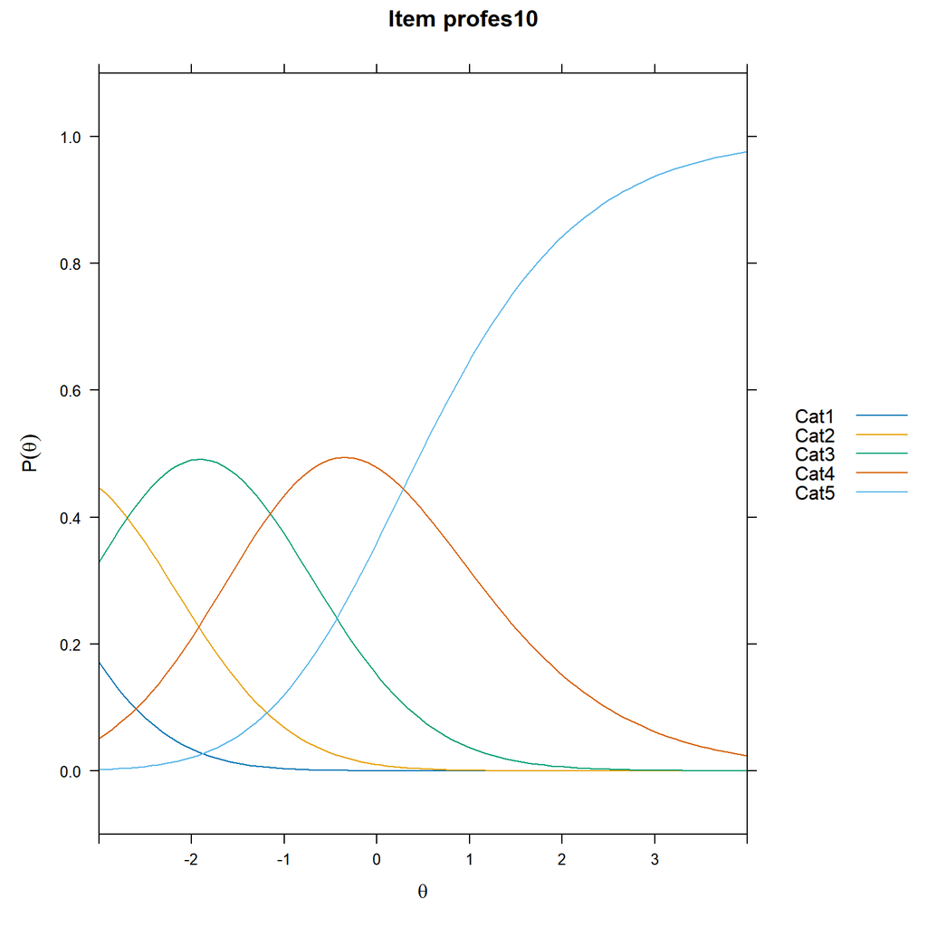

Following the collapse, all remaining categories achieved sufficient observation frequencies. Category probability curves showed improved ordering. **profes10** continued to show severe misfit (Infit MnSq = 1.52, ZSt = 4.74; Outfit MnSq = 1.93, ZSt = 5.32), indicating that its problems are structural — attributable to its reverse-coded nature — and not resolved by category recoding. Removal was therefore indicated. **profes08** continued to show a borderline Infit ZSt = 2.25, with MnSq = 1.24 still within acceptable limits; it was therefore retained pending re-evaluation after item removal. **profes02** remained overfitting (Infit MnSq = 0.65), which is noted but does not warrant removal as overfit reflects redundancy rather than measurement distortion.

## 6.2 Iteration 2: Remove Misfitting Item

Table 10. Item Fit — Iteration 2 (After Item Removal)

| Item | Infit_MnSq | Infit_ZSt | Outfit_MnSq | Outfit_ZSt | Infit_Flag | Outfit_Flag |
| --- | --- | --- | --- | --- | --- | --- |
| profes01 | 0.99 | -0.10 | 0.99 | 0.00 | ok | ok |
| profes02 | 0.69 | -3.57 | 0.71 | -2.22 | misfit | misfit |
| profes03 | 0.96 | -0.44 | 0.94 | -0.49 | ok | ok |
| profes04 | 0.99 | -0.03 | 1.06 | 0.45 | ok | ok |
| profes05 | 1.14 | 1.38 | 0.96 | -0.18 | ok | ok |
| profes06 | 0.96 | -0.34 | 0.90 | -0.74 | ok | ok |
| profes07 | 1.08 | 0.82 | 1.02 | 0.17 | ok | ok |
| profes08 | 1.27 | 2.46 | 0.97 | -0.09 | misfit | ok |
| profes09 | 1.17 | 1.76 | 1.14 | 1.02 | ok | ok |

Table 11. Threshold Locations — Iteration 2

|  | alpha | beta | tau.Cat1 | tau.Cat2 | tau.Cat3 | tau.Cat4 |
| --- | --- | --- | --- | --- | --- | --- |
| profes01 | 1 | -1.4 | -2.1 | -1 | 0.74 | 2.4 |
| profes02 | 1 | -1.8 | -2.1 | -1 | 0.74 | 2.4 |
| profes03 | 1 | -1.2 | -2.1 | -1 | 0.74 | 2.4 |
| profes04 | 1 | -1.7 | -2.1 | -1 | 0.74 | 2.4 |
| profes05 | 1 | -2.2 | -2.1 | -1 | 0.74 | 2.4 |
| profes06 | 1 | -1.4 | -2.1 | -1 | 0.74 | 2.4 |
| profes07 | 1 | -1.5 | -2.1 | -1 | 0.74 | 2.4 |
| profes08 | 1 | -2.7 | -2.1 | -1 | 0.74 | 2.4 |
| profes09 | 1 | -1.6 | -2.1 | -1 | 0.74 | 2.4 |

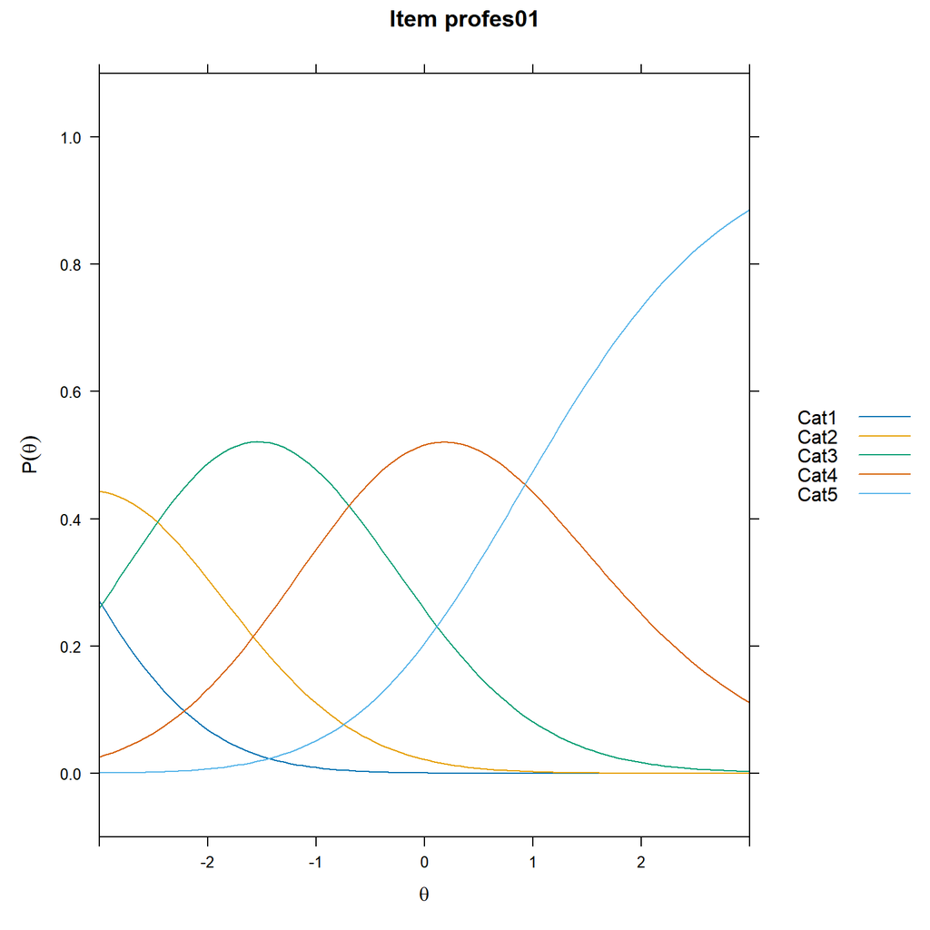

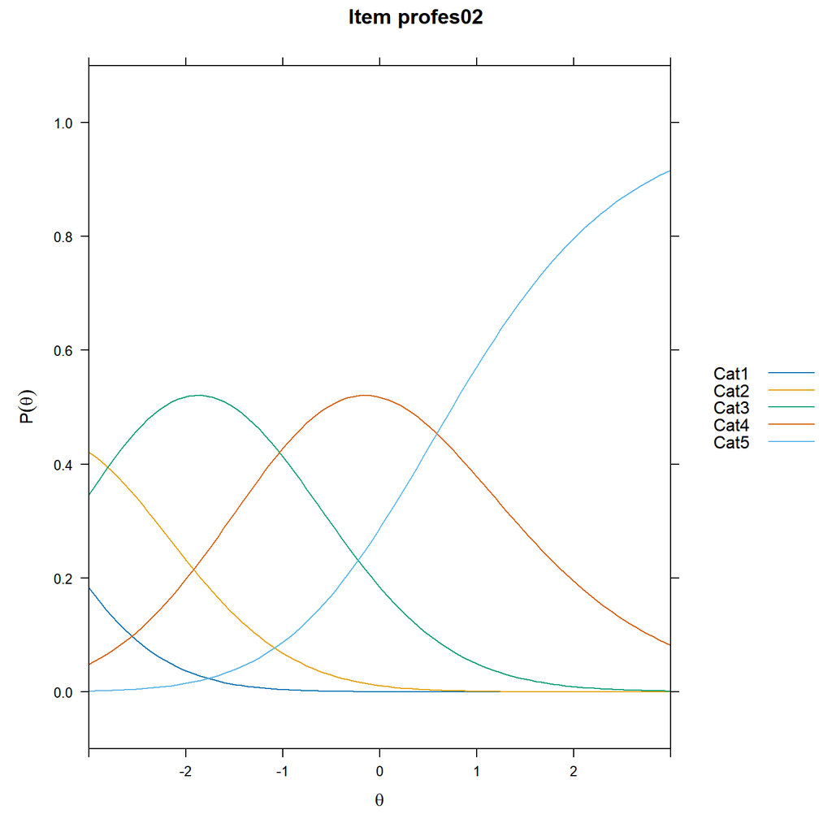

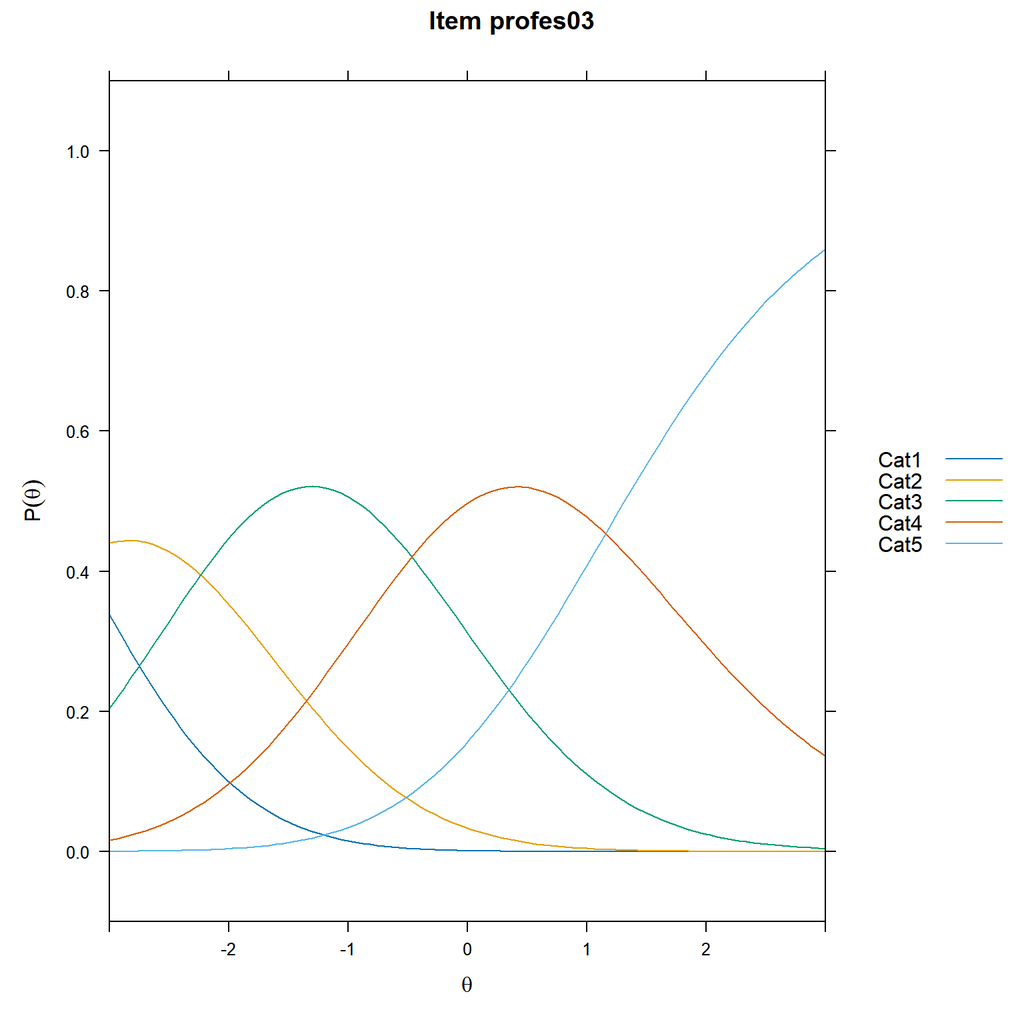

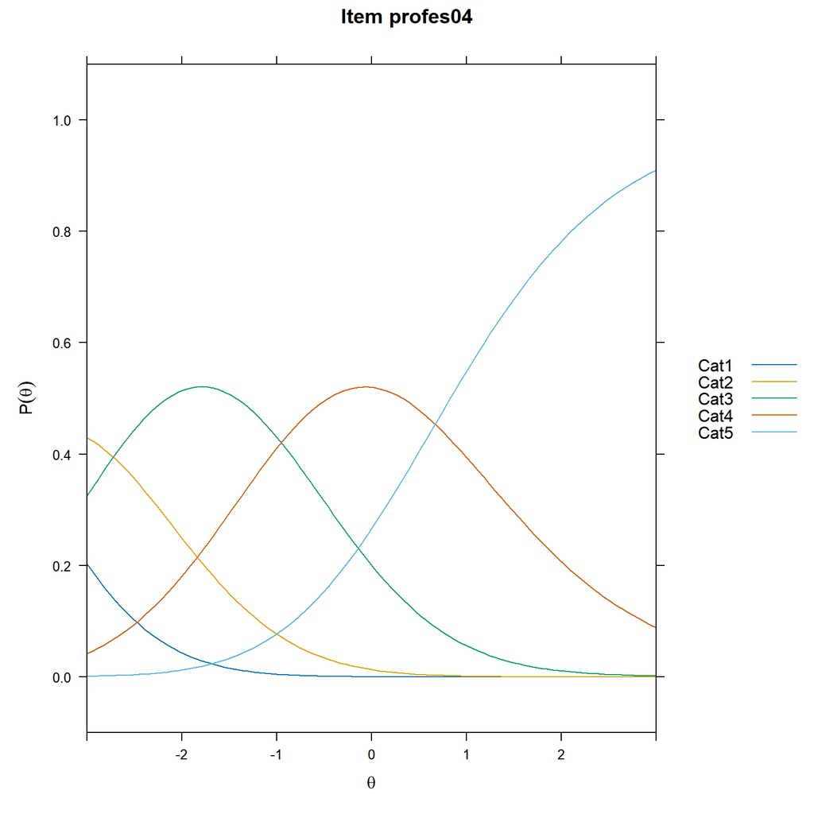

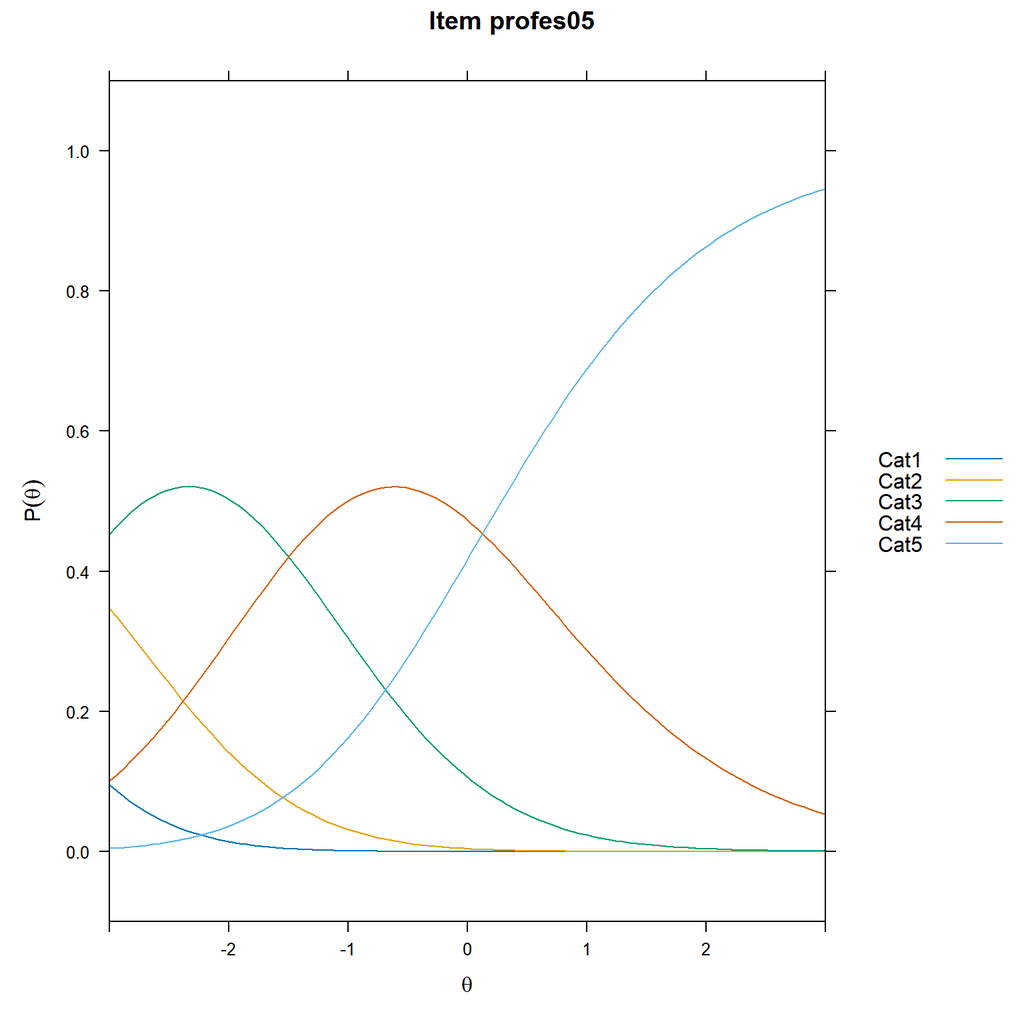

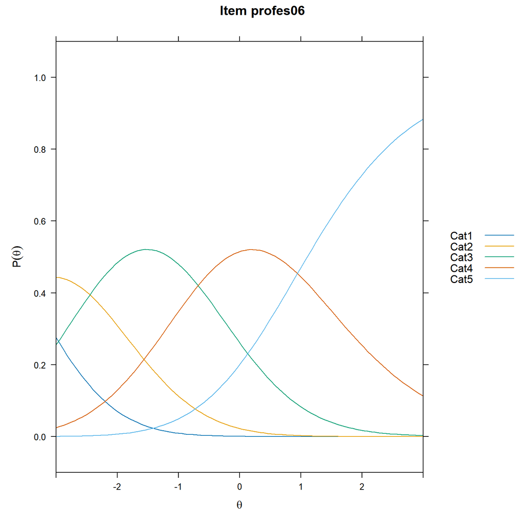

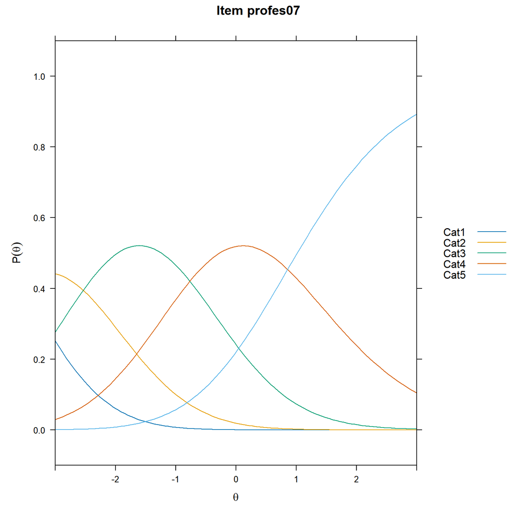

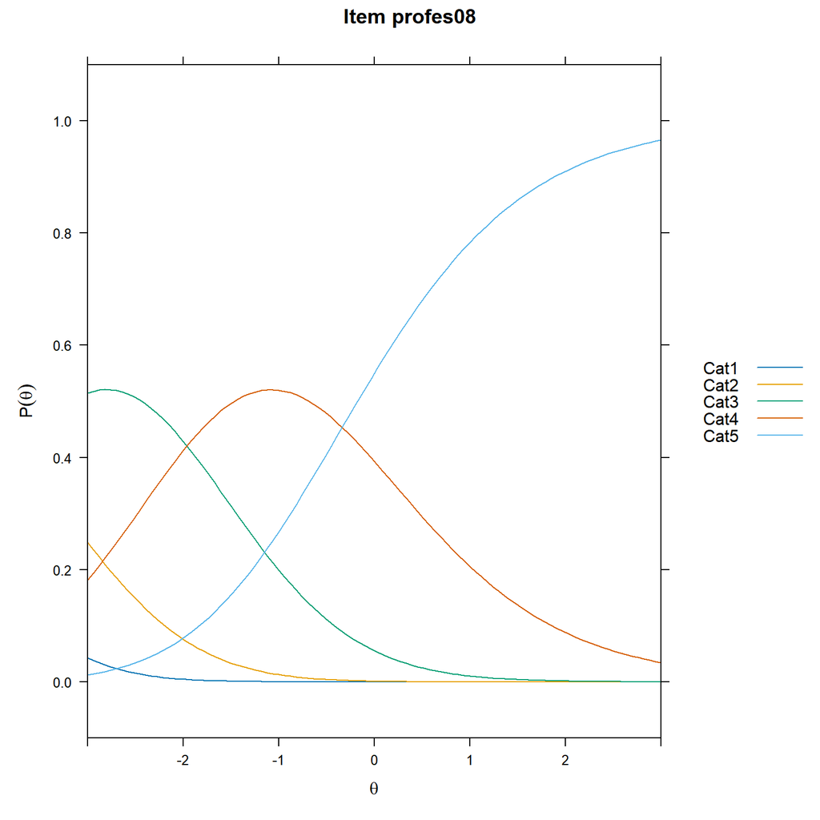

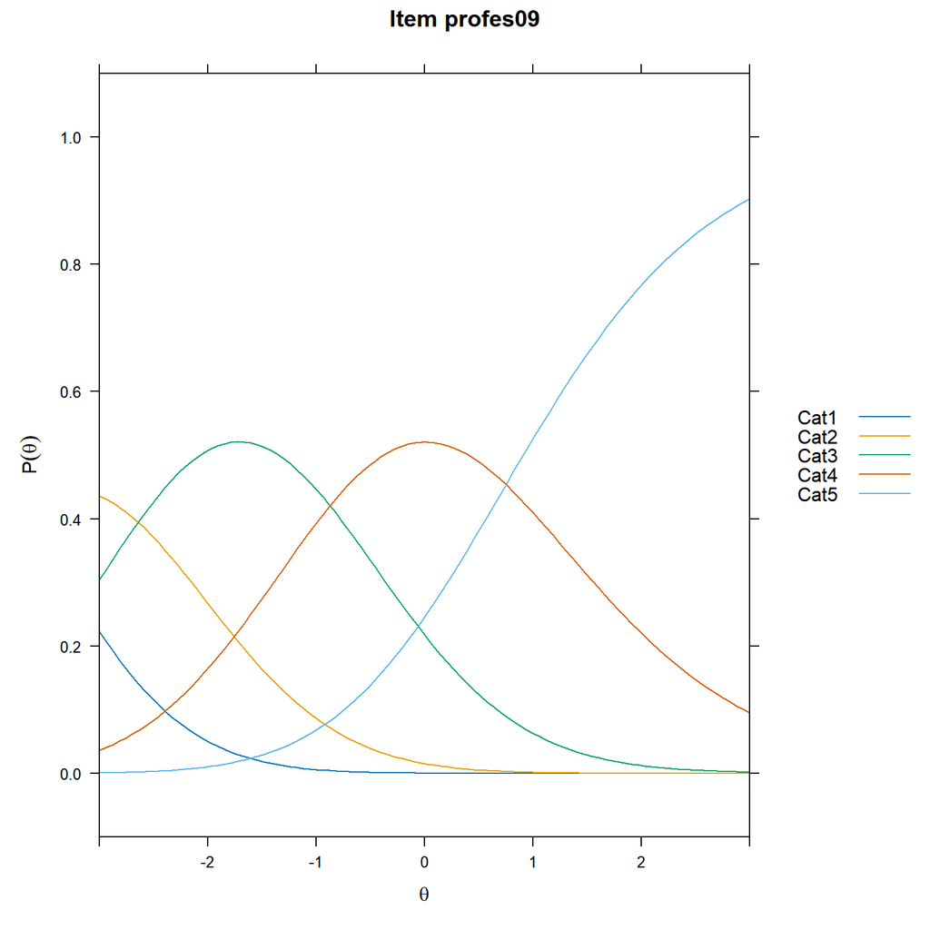

Following the removal of profes10, re-estimation of the model on the remaining nine items yielded substantially improved fit. All items with Outfit $MnSq > 1.4$ were resolved. **profes02** continued to show overfit $(Infit\ MnSq = 0.69,\ ZSt = -3.57;\ Outfit\ MnSq = 0.71,\ ZSt = -2.22)$, indicating overly predictable responses. However, overfit items — unlike underfitting items — do not introduce random noise or distort the latent scale; they are redundant rather than harmful (Wright & Linacre, 1994). Removal was therefore not warranted, and profes02 was retained in the final scale. Regarding **profes08**, its Infit ZSt = 2.46 remains borderline, but its Infit MnSq = 1.27 and Outfit MnSq = 0.97 are both within acceptable bounds. Given that MnSq is the primary fit criterion and ZSt is known to be inflated with larger samples, profes08 is retained in the final scale. This decision should be revisited in future research with independent samples.